# Exercise report on Poisson regression

Author

Mélanie FOURNIER

Published

September 6, 2024

# Poisson regression

The poisson model is as follow:

$$y_i \sim Poi(\lambda(x_i))$$

with $\lambda(x_i) = \exp(\beta_0+ \beta_1 x_{i_1} + \cdots + \beta_p x_{i_p}) = \exp(\beta^T x_i)$.

The log likelihood function is given by

$$l(y | \beta, x) = \sum_{i=1}^n [-\lambda(x_i) + y_i \log(\lambda(x_i))-\log(y_i!)].$$

This log likelihood need to be maximized by setting its gradient to zero, that is

$$f(\beta) = \nabla_{\beta} l(y|\beta, x) = 0$$

The gradient can be calculated elementwise:

$$\frac{\partial l}{\partial \beta_k} = \sum_{i=1}^n -x_{i_k} \lambda(x_i) + y_i x_{i_k}$$

And to solve $f(\beta) = 0$, we can use Newton-Raphson iterations. The Jacobian of $f$ is defined elementwise by:

$$\frac{\partial^2 l}{\partial \beta_k \beta_l} = \sum_{i=1}^n -x_{i_k}x_{i_l} \lambda(x_i)$$

Note that this also gives the observed information matrix, which can be used to derive assymptotic confidence intervals for the parameters.

```python
import pandas as pd
import numpy as np
import matplotlib.pyplot as plt
import os as os
from scipy.special import factorial
from scipy.stats import norm , chi2
```

We create a python object defining the model, with functions that determine the log likelihood and its derivatives with regard to the parameters. Then, Newton-Raphson iterations can be used to maximize this likelihood.

```python
class PoissonModel():
  def __init__(self,x,y):
    """
    Object to define a Poisson model.

    Input:
    - x (np.ndarray), a two dimensional array of dimension (n,p). Note that a 1 column need to be present to account for the intercept
    - y (np.ndarray), the label vector
    """
    self.n , self.p = np.shape(x)
    self.beta = np.zeros(self.p)
    self.x = x
    self.y = y
    pass

  def set_beta(self,beta):
    """
    Used to set beta. Some useful variable are also recomputed automatically as they appear multiple time when using the other functions, so we avoid recomputing them each time.
    In particular, lambda(x_i) is recomputed.
    """
    self.beta = beta
    xbeta = self.x@self.beta
    self.xbeta = xbeta
    self.lmbd = np.exp(xbeta)


  def poisson_loglik(self):
    """
    Compute the log likelihood for the current value of beta
    """
    logy_fact = np.log(factorial(self.y))
    loglik = np.sum(-self.lmbd + self.y*self.xbeta - logy_fact)
    self.loglik = loglik
    return loglik

  def grad_loglik(self):
    """
    Compute the gradient of the log likelihood for the current value of beta
    """
    grad_loglik = np.zeros(self.p)
    for k in range(self.p):
      x_k = self.x[:,k]
      grad_loglik[k] = np.sum(-x_k * self.lmbd) + np.sum(x_k * self.y)
    self.F = grad_loglik
    return self.F

  def grad_loglik2(self):
    #Uses finite differences to compute the gradient of the log likelihood
    grad_loglik = np.zeros(self.p)
    eps = 1e-5
    beta_init = self.beta
    loglik_init = self.poisson_loglik()
    for k in range(self.p):
      beta = np.copy(beta_init)
      beta[k] += eps
      self.set_beta(beta)
      loglik_fd = self.poisson_loglik()
      grad_loglik[k] = (loglik_fd - loglik_init) / eps
      self.set_beta(beta_init)
    self.F = grad_loglik
    return grad_loglik


  def jac(self):
    F_prime = np.zeros((self.p,self.p))
    F_prime2 = np.zeros((self.p,self.p))
    for l in range(self.p):
      for k in range(self.p):
        x_k = self.x[:,k]
        x_l = self.x[:,l]
        F_prime[l,k] = np.sum(-x_k*x_l*self.lmbd)
    self.F_prime = F_prime
    return F_prime



  def newton_iter(self):
    F_prime = self.jac()
    F = self.grad_loglik()
    delta = np.linalg.solve(F_prime,F)
    newbeta = self.beta - delta
    self.set_beta(newbeta)
    return newbeta , delta

  def fit(self):
    for i in range(50):
      beta , delta = self.newton_iter()
      if(np.linalg.norm(delta)<1e-8):
        print('Convergence attained')
        return self.beta
    print('Newtons method may not have converged')
    return self.beta

  def predict(self,x_predict):
    lmbda_pred = np.exp(self.beta@x_predict)
    generated_obs = np.random.poisson(lmbda_pred,1)[0]
    return lmbda_pred, generated_obs

  def _covariance(self):
    """
    Compute the assymptotic variance covariance matrix for the current beta
    """
    obs_fish_matrix = - self.jac()
    self.var = np.linalg.inv(obs_fish_matrix)
    return self.var

  def get_CI_normal(self,alpha):
    """
    Get the confidence interval for the parameter, at level alpha
    """
    var = self._covariance()
    var_diag = np.diag(var) #Extract the diagonal
    plus_min = norm.ppf(1-alpha/2) * np.sqrt(var_diag/self.n)
    self.upr = self.beta + plus_min
    self.lwr = self.beta - plus_min
    print(f'Calculating the confidence interval at level {alpha} using the normal approximation:')
    for i in range(self.p):
      print(f'CI for beta_{i}: [{self.lwr[i]},{self.upr[i]}]')

  def profile_likelihood_plot(self,k,lower=0,upper=100,alpha = 0.05):
    """
    Plot the profile likelihood for beta_k
    """
    beta_init = np.copy(self.beta) #Saving it
    new_beta = np.copy(self.beta)
    initial_loglik = self.poisson_loglik() #For likelihood ratio test
    beta_k_list = np.linspace(lower,upper,100)
    prof_loglik_list = np.zeros_like(beta_k_list)
    for i , beta_k in enumerate(beta_k_list):
      new_beta[k] = beta_k
      self.set_beta(new_beta)
      prof_loglik_list[i] = self.poisson_loglik()
    self.set_beta(beta_init)

    max_deviance = chi2.ppf(1-alpha,1) #Chi square inverse cdf with one degree of freedom
    loglik_threshold = initial_loglik-max_deviance/2 #Likelihood threshold for Cider
    left_side_idx = np.argmax(beta_k_list  > self.beta[k])
    left_side_loglik = prof_loglik_list[:left_side_idx] #Value of the likelihood for beta below one maximizing it
    right_side_loglik = prof_loglik_list[left_side_idx-1:]
    right_side_betak = beta_k_list[left_side_idx-1:]

    idx_left= (np.abs(left_side_loglik - loglik_threshold)).argmin()
    lwr = beta_k_list[idx_left]
    idx_right = (np.abs(right_side_loglik - loglik_threshold)).argmin()
    upr = right_side_betak[idx_right]

    print(f'Profile likelihood based confidence interval at level {alpha} for beta_{k}:')
    print(f'[{lwr},{upr}]')

    #Plotting
    plt.plot(beta_k_list,prof_loglik_list)

    plt.axhline(initial_loglik - max_deviance/2,linestyle = '--')
    plt.axvline(beta_init[k],linestyle = '--')
    plt.axvline(lwr,linestyle='--',color='red')
    plt.axvline(upr,linestyle='--',color = 'red')
    plt.xlabel(f'Beta_{k}')
    plt.ylabel(f'Profile likelihood')
```

# Testing on the bird count data

The bird count data consists of birds count from one site from the year 1999 to the year 2012, thus containing 13 samples.

The variable of interest are:

- count: the bird count for each year
- yr: the years, from 1999 to 2012.

We fit a Poisson regression for the bird count, using the year as a predictor variable.

$$y \sim Poi(\lambda(\text{year}) = \exp(\beta_0 + \beta_1 \text{year}))$$

```python
df = pd.read_csv('bird_count.csv')
df[['count','yr']].describe(percentiles=[0.5])
```

|  | count | yr |
| --- | --- | --- |
| count | 13.000000 | 13.000000 |
| mean | 8.307692 | 2005.692308 |
| std | 3.660251 | 4.289223 |
| min | 2.000000 | 1999.000000 |
| 50% | 9.000000 | 2006.000000 |
| max | 14.000000 | 2012.000000 |

```python
df['Ones'] = 1 #Adding an intercept
x = df[['Ones','yr']].to_numpy()
y = df['count'].to_numpy()

bird_model = PoissonModel(x,y)
bird_model.set_beta(np.array([0,0]))
bird_model.fit()
log_lik = bird_model.poisson_loglik()
print(f'Log likelihood: {log_lik}')
print(f'Beta = {bird_model.beta}')
```

```
Convergence attained
Log likelihood: -34.682627012734095
Beta = [ 6.71792057e+01 -3.24431585e-02]
```

## Uncertainty approximations

There may be some mistakes here but I don’t have the time to double check. In particular, there is a strong difference in results between the two approaches, which I find a bit strange.

### Assymptotic normal approach

The normal approximation of the likelihood function is very much a stretch with so few samples. Regardless, we can compute the approxomate confidence intervals:

```python
bird_model.get_CI_normal(0.05)
```

```
Calculating the confidence interval at level 0.05 using the normal approximation:
CI for beta_0: [41.79292495740496,92.5654864293381]
CI for beta_1: [-0.045103741276384016,-0.01978257575752849]
```

### Profile likelihood based approach

The profile likelihood approach yields much tighter confidence intervals for the parameters. We make the approximation that the deviance function is $\chi^2(1)$ distributed when calculating the profile likelihoods. Given the low sample size, this may not hold very well.

```
Profile likelihood based confidence interval at level 0.05 for beta_0:
[66.98484848484848,67.36060606060606]
```

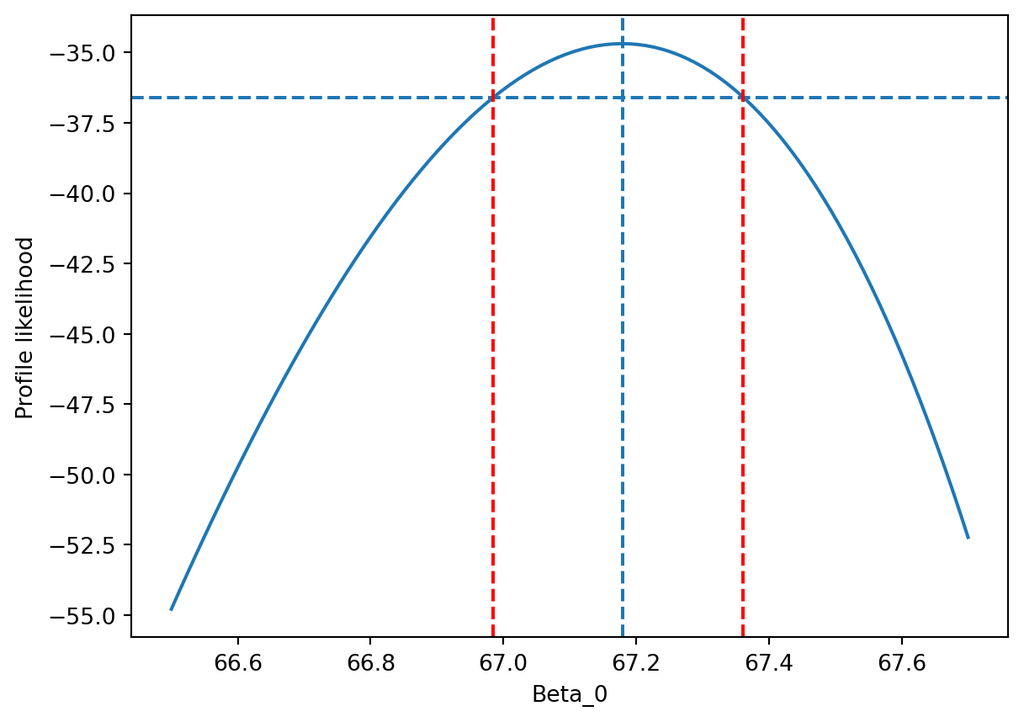

Profile likelihood for the intercept $\beta_0$.

```python
bird_model.profile_likelihood_plot(0,66.5,67.7)
```

```
Profile likelihood based confidence interval at level 0.05 for beta_1:
[-0.03253939393939394,-0.03235353535353535]
```

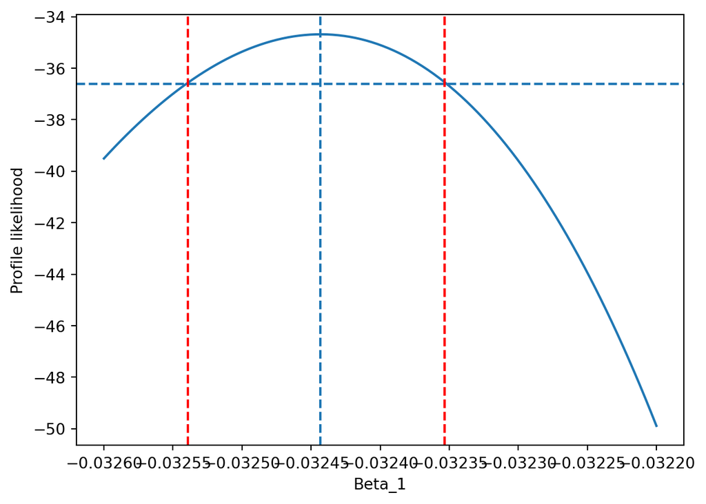

```python
bird_model.profile_likelihood_plot(1,-0.0326,-0.0322)
```

# Generating samples

Now that the model is fit, we can generate some samples for each years. In the table below, the average count is shown as well as the value of lambda associated with the year. There is quite a bit of variance due to how few observations are generated.

```python
np.random.seed(1234)
year_list = np.repeat(np.arange(1999,2012),3) #Generate 3 observations for each year
count_list = np.zeros_like(year_list)
lambda_list = np.zeros_like(year_list,dtype=float) #Lambda hat for the year

for i , year in enumerate(year_list):
  lmbd , count = bird_model.predict(np.array([1,year]))
  count_list[i] = count
  lambda_list[i] = lmbd

d = {'yr': year_list , 'count':count_list,'lmbd_hat':lambda_list}
df_generated = pd.DataFrame(d)
df_generated.groupby('yr').mean()
```

| yr | count | lmbd_hat |
| --- | --- | --- |
| 1999 | 10.000000 | 10.230074 |
| 2000 | 11.333333 | 9.903504 |
| 2001 | 8.666667 | 9.587359 |
| 2002 | 10.333333 | 9.281307 |
| 2003 | 8.333333 | 8.985024 |
| 2004 | 10.333333 | 8.698199 |
| 2005 | 10.666667 | 8.420531 |
| 2006 | 8.333333 | 8.151726 |
| 2007 | 5.666667 | 7.891503 |
| 2008 | 9.000000 | 7.639586 |
| 2009 | 9.333333 | 7.395711 |
| 2010 | 5.333333 | 7.159621 |
| 2011 | 9.333333 | 6.931068 |

And saving the results:

```python
#Saving it

df_generated.to_csv('generated_birds.csv',index = False)
```